```r
library(knitr)
library(devtools)
library(dplyr)
```

```r
library(ggplot2)
library(reshape2)
library(gridExtra)
```

Set the working directory to the subdirectory Fantasy Football Directory where notebooks are saved.

```r
setwd("~/Desktop/FantasyFootball/notebooks")
```

Open the tight end data

```r
df_te <- read.csv("../processed_data/player_data/TE/TE.csv")
head(df_te)
```

```
##   X Rk          Player Pos Week Team Opp Targets Rec Pct Yds TD Long
## 1 1  1  Scott Chandler  TE    1  BUF  KC       5   5 100  63  2   19
## 2 2  2 Aaron Hernandez  TE    1   NE MIA      10   7  70 103  1   30
## 3 3  3  Rob Gronkowski  TE    1   NE MIA       7   6  86  86  1   23
## 4 4  4       Jeff King  TE    1  ARI CAR       3   2  67  61  1   48
## 5 5  5   Dustin Keller  TE    1  NYJ DAL       8   5  63  61  1   19
## 6 6  6      Ed Dickson  TE    1  BAL PIT       5   5 100  59  1   18
##   Yds.Target Yds.Rec Rush Yds_x TD_x Fum Lost Fantasy.Points year week
## 1         13      13    0     0    0   0    0           18.3 2011    1
## 2         10      15    0     0    0   0    0           16.3 2011    1
## 3         12      14    0     0    0   0    0           14.6 2011    1
## 4         20      31    0     0    0   0    0           12.1 2011    1
## 5          8      12    0     0    0   0    0           12.1 2011    1
## 6         12      12    0     0    0   0    0           11.9 2011    1
##   regular.season
## 1              1
## 2              1
## 3              1
## 4              1
## 5              1
## 6              1
```

Get rid of columns that I won’t need.

```r
df_te <- df_te %>% select( -Yds_x, TD_x)
```

Join Table with schedule table to get next week’s oponent.

```r
df_schedules <- read.csv("../processed_data/schedules.csv")

df_te <- df_te %>%  #Add next week's opponent
      left_join(
            df_schedules %>%
                  mutate(previous.week = Week - 1)  %>% #Store the previous week number
                  select(team, year, previous.week, Opponent) %>% # keep only the columns I'll want to join in
                  rename(Next.Opp = Opponent) %>% # rename the next week's opponent column
                  group_by(team, year, previous.week) %>%
                  summarise(Next.Opp = first(Next.Opp)),
            by = c("Team" = "team", "year" = "year", "week" = "previous.week")
      )
```

Store a series of shift statistics: - Next week’s fantasy points earned (this will be the response variable in the analysis to follow) - Previous Week’s target passes - Previous week’s receptions - Previous week’s yards

```r
df_te <- df_te %>%
      group_by(Player, year) %>% # group by player and year to ensure stats stay within the current season
      mutate(
            Next.Fantasy.Points = lead(n = 1, Fantasy.Points), #Add the next week's points
            Previous.Targets = lag(n = 1, Targets), # Previous week's targets
            Previous.Rec = lag(n = 1, Rec), # Previous week's receptions
            Previous.Yds = lag(n = 1, Yds) # Previous week's yards
            ) %>%
      arrange(Player,year,week) # Sort table to see effect of windowing
```

#### Lets do some basic feature extraction

First, I’ll add the average fanatasy points, targets, yards, and receptions from the previous season for each player.

```r
# Add the average fantasy points in that season.
df_te <- df_te %>%
      group_by(Player, year) %>%
      mutate(Avg.Fantasy.Points = mean(Fantasy.Points), # average fantasy points for that year
             Avg.Targets = mean(Targets), # Average targets for that year
             Avg.Rec = mean(Rec), # Average receptions for that year
             Avg.Yds = mean(Yds) # Average yards for that year
      )

# Add columns for these averages from the previous season.
df_te <-  df_te %>%
      left_join(
            df_te %>%
                  mutate(next.year = year +1) %>% # Add column for next year
                  group_by(Player, year) %>%
                  mutate(
                              Previous.Avg.Fantasy.Points = first(Avg.Fantasy.Points), #Add average fantasy points
                              Previous.Avg.Targets = first(Avg.Targets), # Add average targets
                              Previous.Avg.Rec = first(Avg.Rec), # Add average receptions
                              Previous.Avg.Yds = first(Avg.Yds)
                        ) %>%
                  filter(row_number() == 1) %>%  #Only keep one row per player/year group to avoid duplication upon join
                  select(Player, next.year, Previous.Avg.Fantasy.Points, Previous.Avg.Targets, Previous.Avg.Rec, Previous.Avg.Yds)
                  ,
            by = c("Player" = "Player", "year" = "next.year")
            ) %>%
            ungroup()
```

Next, compute a series of cumulative average statistics. These will be the average number of fantasy ponts, targets, receptions, and yards for a player within that season up to (and including) a certain week.

```r
df_te <- df_te %>%
      group_by(Player, year) %>%  #Look at players one season at a time
      arrange(week) %>%
      mutate(
            Cum.Avg.Fantasy.Points = cummean(Fantasy.Points), #cumualtive average number of fantasy points per game
            Cum.Avg.Targets = cummean(Targets), #cumulative average number of targets per game
            Cum.Avg.Rec = cummean(Rec), #cumulative average number of receptions per game
            Cum.Avg.Yds = cummean(Yds), #cumulative average number of yards per game
            Cum.Avg.TD = cummean(TD) #cumalative average number of TDs
      ) %>%
      ungroup()
```

Now, see if the player has increased in performance from previous week to current week. This may suggest that player is on short term “hot streak.”

```r
df_te <- df_te %>%
      mutate(
            Target.Increase = Targets - Previous.Targets, #See the increase/decrease in targets from previous week
            Yds.Increase = Yds - Previous.Yds,
            Rec.Increase = Rec - Previous.Rec
      )
```

Now, I’d like to add some features that show how the opposing team does against this player. First, I’ll add the average number of fantasy points let up by the opponent to players of the position in quetion in the previous two seasons.

```r
df_te <- df_te %>%
      left_join( #add the average points let up by opponent in previous year
            df_te %>%
                  group_by(Opp, year) %>%
                  summarise(Avg.Points.Allowed.Last.Year = mean(Fantasy.Points)) %>% #average fantasy points allowed by opponent last year
                  ungroup() %>%
                  mutate(next.year = year + 1) #will be used to join with year column to get last year's avg points allowed
      ,
      by = c("Next.Opp" = "Opp", "year" = "next.year")
      ) %>%
      left_join( #add the average points let up by next week's opponent two years ago
            df_te %>%
                  group_by(Opp, year) %>%
                  summarise(Avg.Points.Allowed.Last.Last.Year = mean(Fantasy.Points)) %>% #average fantasy points allowed by opponent last year
                  ungroup() %>%
                  mutate(next.next.year = year + 2) #will be used to join with year column to get last year's avg points allowed
      ,
      by = c("Next.Opp" = "Opp", "year" = "next.next.year")
      )
# When Next.Opp is NA, it means that there is no team to be played next week because the player will be on a bye week.
# This will cause the columns 'Avg.Points.Allowed.Last.Year' and 'Avg.Points.Allowed.Last.Last.Year' to be NA as well.
# Since I want to use these columns for my model, I'll fill the with something reasonable - the average amount of points allowed.
df_te[is.na(df_te$Avg.Points.Allowed.Last.Year), "Avg.Points.Allowed.Last.Year"] <- mean(df_te$Avg.Points.Allowed.Last.Year, na.rm = TRUE)
df_te[is.na(df_te$Avg.Points.Allowed.Last.Last.Year), "Avg.Points.Allowed.Last.Last.Year"] <- mean(df_te$Avg.Points.Allowed.Last.Last.Year, na.rm = TRUE)
```

Finally, I’ll add in how many years the player appears in the dataset (since 2011). I just want to see if rookies don’t do well in general.

```r
df_te <-  df_te %>%
      group_by(Player) %>%
      mutate(num.years.playing = n_distinct(year)) %>%
      ungroup()
```

#### Quick Data Cleaning

Fantasy points are positively skewked. Sometimes. People do uncharactaristially well.

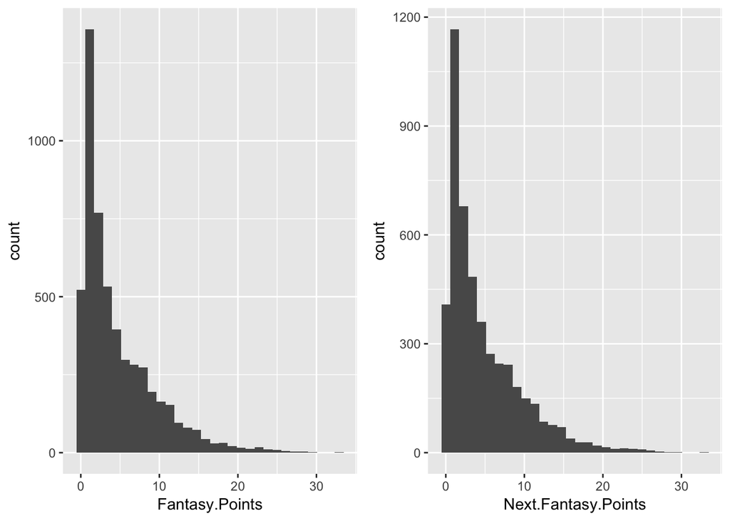

```r
# A look at outliers
g_hist_points <- df_te %>% ggplot(aes(x=Fantasy.Points)) + geom_histogram()
g_hist_next_points <- df_te %>% ggplot(aes(x=Next.Fantasy.Points)) + geom_histogram()
grid.arrange(g_hist_points, g_hist_next_points, ncol=2)
```

I use many lagged statistics from previous years. This has two problems. First, the state of Football has changed in recent times - offenses are more productive than they used to be. It may not make sense to a model to data from too far back. Second, many of the features I extract rely on looking back to performances of previous years. This results in NA’s if there are no years to look back to in the datast.

As such, I will remove the two earliest years in the dataset - 2011 and 2012.

```r
df_te <- df_te %>% filter(year > 2012)
```

To determine if a performance is “uncharactaristic”, I’ll use the boxplot (Tukey) outlier method.

```r
test <-
df_te %>% #Join to get the upper and lower Tukey thresholds for a player's fantasy points, based on data since 2014.
      left_join(
                df_te %>%
                      group_by(Player) %>% #finding average for each player
                      summarize(
                            Q25.Fantasy.Points = quantile(Fantasy.Points, probs = .25), #25th quantile of fantasy points earned in games since 2014
                            Q75.Fantasy.Points = quantile(Fantasy.Points, probs = .75) #75th quantile of fantasy points earned in games since 2014
                      ) %>%
                      mutate( IQR.Fantasy.Points = Q75.Fantasy.Points - Q25.Fantasy.Points) %>% #Get the IQR of fantasy points earned since 2014
                      mutate(
                            Lower.Limit.Fantasy.Points = Q25.Fantasy.Points - 3*IQR.Fantasy.Points,
                            Upper.Limit.Fantasy.Points = Q75.Fantasy.Points + 3*IQR.Fantasy.Points #calculate lower and upper tukey limits
                      ) %>%
                      select(Player, Lower.Limit.Fantasy.Points, Upper.Limit.Fantasy.Points) #keep only columns I want to bring over in join
                ,
                by = "Player"
      ) %>%
      filter( Fantasy.Points >= Lower.Limit.Fantasy.Points & Fantasy.Points <= Upper.Limit.Fantasy.Points)
```

Fill NA values in test

```r
test[is.na(test)] <- 0
```

### Create a dummy model

```r
model <- lm(data = test, Next.Fantasy.Points ~ Cum.Avg.Rec + Cum.Avg.Targets + Cum.Avg.Yds + Cum.Avg.TD + Previous.Avg.Targets + Avg.Points.Allowed.Last.Year ,  na.action = na.exclude )

summary(model)
```

```
##
## Call:
## lm(formula = Next.Fantasy.Points ~ Cum.Avg.Rec + Cum.Avg.Targets +
##     Cum.Avg.Yds + Cum.Avg.TD + Previous.Avg.Targets + Avg.Points.Allowed.Last.Year,
##     data = test, na.action = na.exclude)
##
## Residuals:
##     Min      1Q  Median      3Q     Max
## -11.157  -2.598  -1.190   1.680  24.324
##
## Coefficients:
##                               Estimate Std. Error t value Pr(>|t|)
## (Intercept)                  -0.432194   0.465179  -0.929  0.35290
## Cum.Avg.Rec                  -0.430992   0.167657  -2.571  0.01019 *
## Cum.Avg.Targets               0.540088   0.109133   4.949 7.81e-07 ***
## Cum.Avg.Yds                   0.045416   0.008805   5.158 2.63e-07 ***
## Cum.Avg.TD                    1.142183   0.276926   4.125 3.80e-05 ***
## Previous.Avg.Targets          0.185458   0.036559   5.073 4.12e-07 ***
## Avg.Points.Allowed.Last.Year  0.266885   0.094043   2.838  0.00457 **
## ---
## Signif. codes:  0 '***' 0.001 '**' 0.01 '*' 0.05 '.' 0.1 ' ' 1
##
## Residual standard error: 4.349 on 3547 degrees of freedom
## Multiple R-squared:  0.1797, Adjusted R-squared:  0.1783
## F-statistic: 129.5 on 6 and 3547 DF,  p-value: < 2.2e-16
```

See how these things are correlated (high multicolinearity expected)

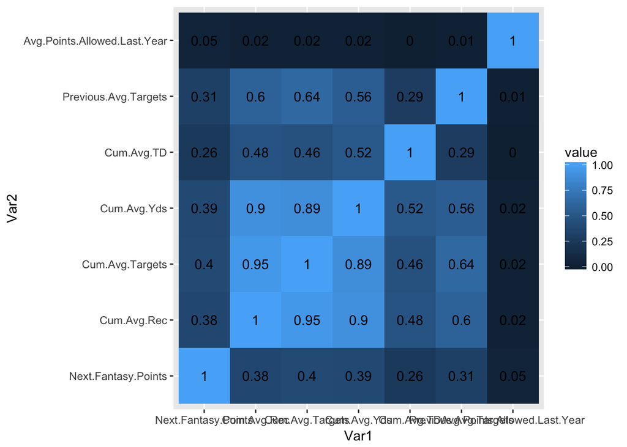

```r
melt(
      cor(
            test %>%
                  select(Next.Fantasy.Points, Cum.Avg.Rec , Cum.Avg.Targets , Cum.Avg.Yds , Cum.Avg.TD , Previous.Avg.Targets , Avg.Points.Allowed.Last.Year)
      )
) %>%
      ggplot( aes(x = Var1, y = Var2, fill = value, label = round(value, 2)) ) + geom_tile() + geom_text()
```

Add predicitions

```r
test$Predictions = predict(model)
test$Residuals = resid(model)
```

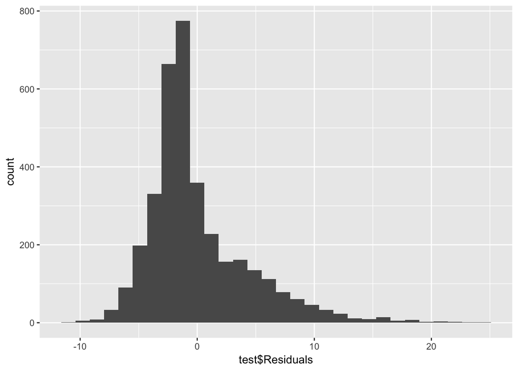

```r
qplot(test$Residuals)
```

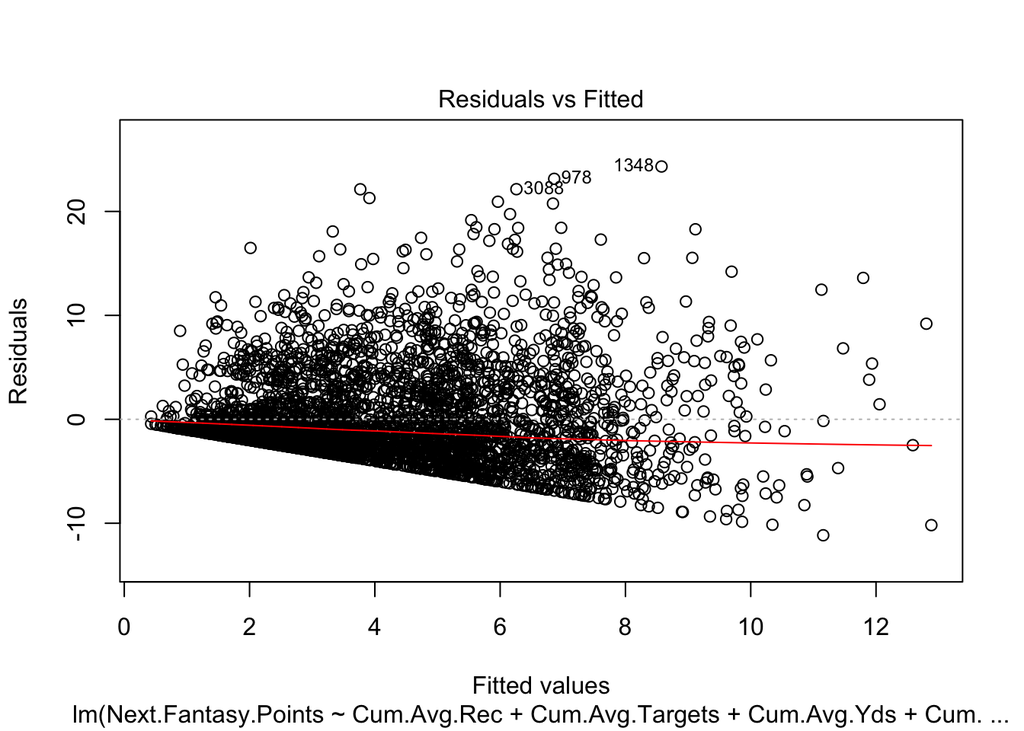

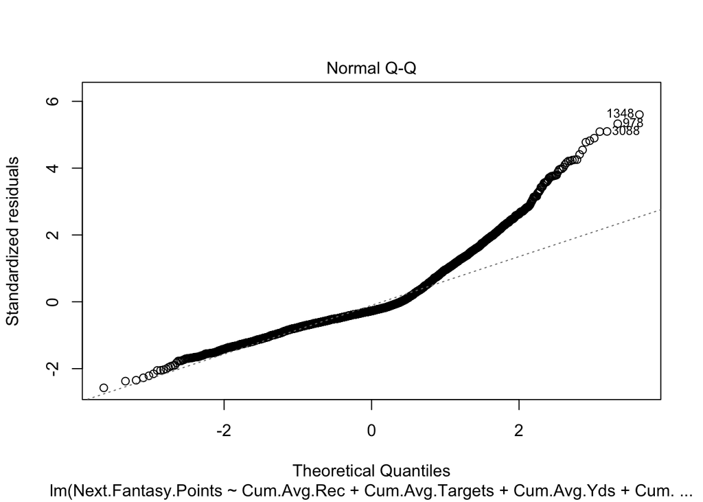

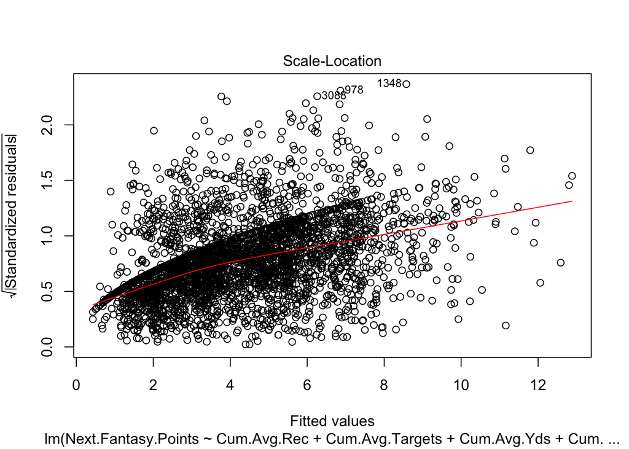

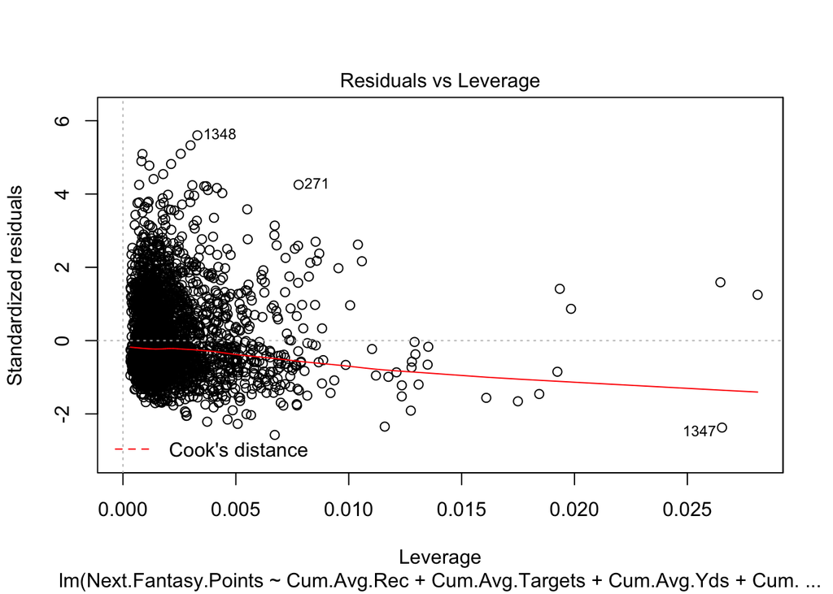

```r
plot(model)
```